# EXERCISE_ON_Clustering

**Answer Questions 1 to 5 using the customerspends.csv Dataset**

An online grocery store has captured amount spent per annum (in Indian rupees) by 20 customers on apparel and beauty and healthcare products and given in the file customerspends.csv. It contains the following records.

- *Customer* - Customer ID
- *Apparel* - Amount spent in apparel products
- *Beauty and Healthcare* - Amount spent in beauty and healthcare products

```python
import warnings
warnings.filterwarnings ('ignore')
import pandas as pd
customers_df = pd.read_csv("customerspends.csv")
customers_df.head()
```

|  | Customer | Apparel | Beauty and Healthcare |
| --- | --- | --- | --- |
| 0 | 1 | 21.10 | 0.7 |
| 1 | 2 | 15.23 | 5.5 |
| 2 | 3 | 5.22 | 18.6 |
| 3 | 4 | 31.10 | 1.8 |
| 4 | 5 | 6.12 | 21.5 |

1. Create a scatter plot to depict the customer spends on apparel and beauty and healthcare products.

Identify number of clusters existing in the dataset.

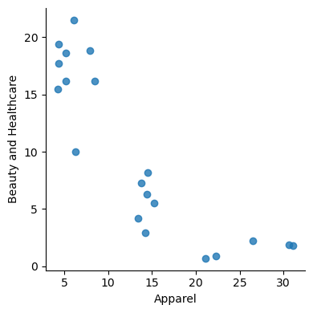

```python
import seaborn as sns
import matplotlib.pyplot as plt
sns.lmplot(x="Apparel", y="Beauty and Healthcare", data=customers_df, fit_reg=False, height=4)
plt.show()
```

```python
from sklearn.cluster import KMeans
clusters = KMeans(3)
clusters.fit(customers_df)
```

```
KMeans(n_clusters=3)
```

```python
customers_df["clusterid"] = clusters.labels_
customers_df.head()
```

|  | Customer | Apparel | Beauty and Healthcare | clusterid |
| --- | --- | --- | --- | --- |
| 0 | 1 | 21.10 | 0.7 | 0 |
| 1 | 2 | 15.23 | 5.5 | 2 |
| 2 | 3 | 5.22 | 18.6 | 1 |
| 3 | 4 | 31.10 | 1.8 | 0 |
| 4 | 5 | 6.12 | 21.5 | 1 |

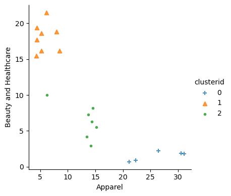

```python
import seaborn as sns
import matplotlib.pyplot as plt
markers = ['+', '^', '.']
sns.lmplot(x="Apparel", y="Beauty and Healthcare", data=customers_df, hue="clusterid", fit_reg=False, markers=markers, height=4)
plt.show()
```

2. Normalize the features using StandardScaler and plot them in the scatter plot again.

```python
from sklearn.preprocessing import StandardScaler
scaler = StandardScaler()
scaled_customers_df = scaler.fit_transform(
customers_df[["Apparel", "Beauty and Healthcare"]])
scaled_customers_df[0:5]
```

```
array([[ 0.892371  , -1.26688022],
       [ 0.20647107, -0.59775334],
       [-0.96318111,  1.22840542],
       [ 2.06085469, -1.11353864],
       [-0.85801758,  1.63266957]])
```

```python
from sklearn.cluster import KMeans
clusters_new = KMeans (3, random_state=42)
clusters_new.fit(scaled_customers_df)
customers_df["clusterid_new"] = clusters_new.labels_
```

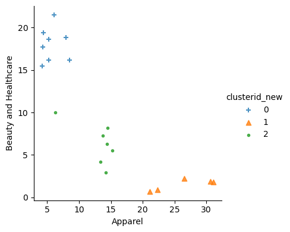

```python
import seaborn as sns
import matplotlib.pyplot as plt
markers = ['+', '^', '.']
sns.lmplot(x="Apparel", y="Beauty and Healthcare", data=customers_df, hue="clusterid_new", fit_reg=False, markers=markers, height=4)
plt.show()
```

3. Use dendrogram and elbow method to verify if the number of clusters suggested is same as clusters

visible in the scatter plot in Question 1.

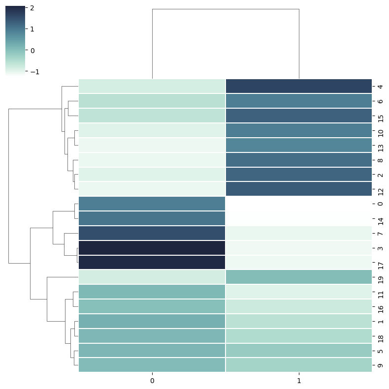

```python
import seaborn as sn
cmap = sn.cubehelix_palette(as_cmap=True, rot=-.3, light=1)
sn.clustermap (scaled_customers_df, cmap=cmap, linewidths=.2,
figsize = (8,8));
```

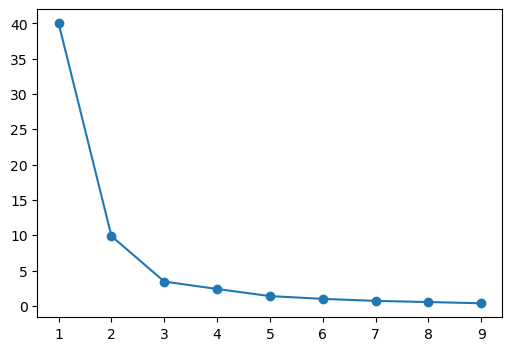

```python
import warnings
warnings.filterwarnings ('ignore')
from sklearn.cluster import KMeans
import matplotlib.pyplot as plt
cluster_range = range(1, 10)
cluster_errors = []
for num_clusters in cluster_range:
    clusters = KMeans (num_clusters )
    clusters.fit(scaled_customers_df)
    cluster_errors.append(clusters.inertia_)
plt.figure(figsize=(6,4))
plt.plot(cluster_range, cluster_errors, marker = "o");
```

4. Create the number of clusters as suggested by the elbow method using K-means algorithm.

```python
k = 3
clusters = KMeans (k, random_state = 42 )
clusters.fit(scaled_customers_df)
customers_df["clusterid"] = clusters.labels_
```

```python
from sklearn.cluster import AgglomerativeClustering
h_clusters = AgglomerativeClustering (3)
h_clusters.fit(scaled_customers_df )
customers_df["h_clusterid"] = h_clusters.labels_
```

5. Print the records of customersin each cluster and the cluster center of each clusterseparately.

Explain the clusters intuitively

```python
customers_df[customers_df.clusterid == 0]
```

|  | Customer | Apparel | Beauty and Healthcare | clusterid | clusterid_new | h_clusterid |
| --- | --- | --- | --- | --- | --- | --- |
| 2 | 3 | 5.22 | 18.6 | 0 | 0 | 1 |
| 4 | 5 | 6.12 | 21.5 | 0 | 0 | 1 |
| 6 | 7 | 8.50 | 16.2 | 0 | 0 | 1 |
| 8 | 9 | 4.34 | 17.7 | 0 | 0 | 1 |
| 10 | 11 | 5.20 | 16.2 | 0 | 0 | 1 |
| 12 | 13 | 4.40 | 19.4 | 0 | 0 | 1 |
| 13 | 14 | 4.25 | 15.5 | 0 | 0 | 1 |
| 15 | 16 | 7.90 | 18.8 | 0 | 0 | 1 |

```python
customers_df[customers_df.clusterid == 1]
```

|  | Customer | Apparel | Beauty and Healthcare | clusterid | clusterid_new | h_clusterid |
| --- | --- | --- | --- | --- | --- | --- |
| 0 | 1 | 21.1 | 0.7 | 1 | 1 | 2 |
| 3 | 4 | 31.1 | 1.8 | 1 | 1 | 2 |
| 7 | 8 | 26.5 | 2.2 | 1 | 1 | 2 |
| 14 | 15 | 22.3 | 0.9 | 1 | 1 | 2 |
| 17 | 18 | 30.6 | 1.9 | 1 | 1 | 2 |

```python
customers_df[customers_df.clusterid == 2]
```

|  | Customer | Apparel | Beauty and Healthcare | clusterid | clusterid_new | h_clusterid |
| --- | --- | --- | --- | --- | --- | --- |
| 1 | 2 | 15.23 | 5.50 | 2 | 2 | 0 |
| 5 | 6 | 14.50 | 8.20 | 2 | 2 | 0 |
| 9 | 10 | 13.75 | 7.30 | 2 | 2 | 0 |
| 11 | 12 | 14.20 | 2.90 | 2 | 2 | 0 |
| 16 | 17 | 13.40 | 4.20 | 2 | 2 | 0 |
| 18 | 19 | 14.40 | 6.28 | 2 | 2 | 0 |
| 19 | 20 | 6.25 | 9.98 | 2 | 2 | 0 |

```python
customers_df.groupby('clusterid')[['Apparel', 'Beauty and Healthcare']].agg(["mean",'std']).reset_index()
```

|  | clusterid | Apparel mean | Apparel std | Beauty and Healthcare mean | Beauty and Healthcare std |
| --- | --- | --- | --- | --- | --- |
| 0 | 0 | 5.741250 | 1.646003 | 17.987500 | 2.001027 |
| 1 | 1 | 26.320000 | 4.599130 | 1.500000 | 0.659545 |
| 2 | 2 | 13.104286 | 3.077655 | 6.337143 | 2.406697 |

**Answer Questions 6 to 10 using the Online Retail.xlsx Dataset**

The dataset Online Retail.xlsx and the description of the data is taken from https://archive.ics.uci.edu/ml/ datasets/online+retail.

Online Retail.xlsx contains records of transactions occurring between 01/12/2010 and 09/12/2011 for a UK-based and registered non-store online retail.

The company mainly sells unique all-occasion gifts.

Many customers of the company are wholesalers.

The attributes in the dataset are:

- *InvoiceN* - Invoice number. Nominal, a 6-digit integral number uniquely assigned to each transaction. If this code starts with letter “c”, it indicates a cancellation.
- *StockCode* - Product (item) code. Nominal, a 5-digit integral number uniquely assigned to each

distinct product.

- *Description* - Product (item) name. Nominal.
- *Quantity* - The quantities of each product (item) per transaction. Numeric.
- *InvoiceDate* - Invoice Date and time. Numeric, the day and time when each transaction was

generated.

- *UnitPrice* - Unit price. Numeric, Product price per unit in sterling.
- *CustomerID* - Customer number. Nominal, a 5-digit integral number uniquely assigned to each

customer.

- *Country* - Country name. Nominal, the name of the country where each customer resides.

```python
import warnings
warnings.filterwarnings ('ignore')
import pandas as pd
online_retail_df = pd.read_excel("Online Retail.xlsx")
online_retail_df.head()
```

|  | InvoiceNo | StockCode | Description | Quantity | InvoiceDate | UnitPrice | CustomerID | Country |
| --- | --- | --- | --- | --- | --- | --- | --- | --- |
| 0 | 536365 | 85123A | WHITE HANGING HEART T-LIGHT HOLDER | 6 | 2010-12-01 08:26:00 | 2.55 | 17850.0 | United Kingdom |
| 1 | 536365 | 71053 | WHITE METAL LANTERN | 6 | 2010-12-01 08:26:00 | 3.39 | 17850.0 | United Kingdom |
| 2 | 536365 | 84406B | CREAM CUPID HEARTS COAT HANGER | 8 | 2010-12-01 08:26:00 | 2.75 | 17850.0 | United Kingdom |
| 3 | 536365 | 84029G | KNITTED UNION FLAG HOT WATER BOTTLE | 6 | 2010-12-01 08:26:00 | 3.39 | 17850.0 | United Kingdom |
| 4 | 536365 | 84029E | RED WOOLLY HOTTIE WHITE HEART. | 6 | 2010-12-01 08:26:00 | 3.39 | 17850.0 | United Kingdom |

6. Select only the transactions that have occurred in the year 06/01/11 and 11/30/11 and create a new

subset of data. For answering questions from 7 to 10, use this subset of data.

```python
online_retail_df['InvoiceDate'] = pd.to_datetime(online_retail_df['InvoiceDate'])
start_date = '2011-06-01'
end_date = '2011-11-30'
filtered_online_retail_df = online_retail_df[(online_retail_df['InvoiceDate'] >= start_date) & (online_retail_df['InvoiceDate'] <= end_date)]
filtered_online_retail_df.head()
```

|  | InvoiceNo | StockCode | Description | Quantity | InvoiceDate | UnitPrice | CustomerID | Country |
| --- | --- | --- | --- | --- | --- | --- | --- | --- |
| 209029 | 555156 | 23299 | FOOD COVER WITH BEADS SET 2 | 6 | 2011-06-01 07:37:00 | 3.75 | 15643.0 | United Kingdom |
| 209030 | 555156 | 22847 | BREAD BIN DINER STYLE IVORY | 1 | 2011-06-01 07:37:00 | 16.95 | 15643.0 | United Kingdom |
| 209031 | 555157 | 23075 | PARLOUR CERAMIC WALL HOOK | 16 | 2011-06-01 07:38:00 | 4.15 | 15643.0 | United Kingdom |
| 209032 | 555157 | 47590B | PINK HAPPY BIRTHDAY BUNTING | 6 | 2011-06-01 07:38:00 | 5.45 | 15643.0 | United Kingdom |
| 209033 | 555157 | 22423 | REGENCY CAKESTAND 3 TIER | 4 | 2011-06-01 07:38:00 | 12.75 | 15643.0 | United Kingdom |

7. Calculate the RFM values for each customer (by customer id). RFM represents
- R (Recency) - Recency should be calculated as the number of months before he or she has made

a purchase from the online store. If he/she made a purchase in the month of November 2011, then the Recency should be 0. If purchase is made in October 2011 then Recency should be 1 and so on and so forth.

- F (Frequency) - Number of invoices by the customer from 06/01/11 to 11/30/11.
- M (Monetary Value) - Total spend by the customer from 06/01/11 to 11/30/11.

```python
latest_date = filtered_online_retail_df['InvoiceDate'].max()
recency_df = filtered_online_retail_df.groupby('CustomerID')['InvoiceDate'].max().reset_index()
recency_df['Recency'] = ((latest_date - recency_df['InvoiceDate']) / pd.Timedelta(days=30)).round().astype(int)
```

```python
frequency_df = filtered_online_retail_df.groupby('CustomerID')['InvoiceNo'].nunique().reset_index()
frequency_df.columns = ['CustomerID', 'Frequency']
```

```python
filtered_online_retail_df['TotalPrice'] = filtered_online_retail_df['Quantity'] * filtered_online_retail_df['UnitPrice']
monetary_df = filtered_online_retail_df.groupby('CustomerID')['TotalPrice'].sum().reset_index()
monetary_df.columns = ['CustomerID', 'Monetary']
```

```python
rfm_df = recency_df.merge(frequency_df, on='CustomerID').merge(monetary_df, on='CustomerID')
rfm_df.head()
```

|  | CustomerID | InvoiceDate | Recency | Frequency | Monetary |
| --- | --- | --- | --- | --- | --- |
| 0 | 12347.0 | 2011-10-31 12:25:00 | 1 | 3 | 2261.75 |
| 1 | 12348.0 | 2011-09-25 13:13:00 | 2 | 1 | 310.00 |
| 2 | 12349.0 | 2011-11-21 09:51:00 | 0 | 1 | 1757.55 |
| 3 | 12352.0 | 2011-11-03 14:37:00 | 1 | 3 | 944.23 |
| 4 | 12356.0 | 2011-11-17 08:40:00 | 0 | 1 | 58.35 |

8. Use dendrogram and elbow method to identify how many customer segments exist, using the RFM

values for each customer created in Question 7.

```python
from sklearn.preprocessing import StandardScaler
scaler = StandardScaler()
scaled_rfm_df = scaler.fit_transform(rfm_df[['Recency', 'Frequency', 'Monetary']])
```

[figure not shown]

```python
import seaborn as sn
cmap = sn.cubehelix_palette(as_cmap=True, rot=-.3, light=1)
sn.clustermap (scaled_rfm_df, cmap=cmap, linewidths=.2,
figsize = (10, 8));
```

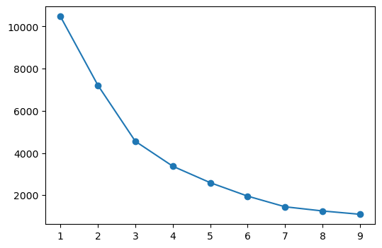

```python
import warnings
warnings.filterwarnings ('ignore')
from sklearn.cluster import KMeans
import matplotlib.pyplot as plt
cluster_range = range(1, 10)
cluster_errors = []
for num_clusters in cluster_range:
    clusters = KMeans (num_clusters )
    clusters.fit(scaled_rfm_df)
    cluster_errors.append(clusters.inertia_)
plt.figure(figsize=(6,4))
plt.plot(cluster_range, cluster_errors, marker = "o");
```

9. Create the customer segments with K-means algorithm by using number of clusters is suggested by

elbow method.

```python
k = 4
clusters = KMeans (k, random_state = 42 )
clusters.fit(scaled_rfm_df)
rfm_df["clusterid"] = clusters.labels_
```

10. Print the cluster centers of each customer segment and explain them intuitively.

```python
rfm_df[rfm_df.clusterid == 0]
```

|  | CustomerID | InvoiceDate | Recency | Frequency | Monetary | clusterid |
| --- | --- | --- | --- | --- | --- | --- |
| 0 | 12347.0 | 2011-10-31 12:25:00 | 1 | 3 | 2261.75 | 0 |
| 1 | 12348.0 | 2011-09-25 13:13:00 | 2 | 1 | 310.00 | 0 |
| 2 | 12349.0 | 2011-11-21 09:51:00 | 0 | 1 | 1757.55 | 0 |
| 3 | 12352.0 | 2011-11-03 14:37:00 | 1 | 3 | 944.23 | 0 |
| 4 | 12356.0 | 2011-11-17 08:40:00 | 0 | 1 | 58.35 | 0 |
| ... | ... | ... | ... | ... | ... | ... |
| 3485 | 18276.0 | 2011-11-18 17:01:00 | 0 | 3 | 323.36 | 0 |
| 3486 | 18277.0 | 2011-10-12 15:22:00 | 2 | 1 | 110.38 | 0 |
| 3487 | 18278.0 | 2011-09-27 11:58:00 | 2 | 1 | 173.90 | 0 |
| 3490 | 18283.0 | 2011-11-23 13:27:00 | 0 | 9 | 1128.22 | 0 |
| 3491 | 18287.0 | 2011-10-28 09:29:00 | 1 | 2 | 1072.00 | 0 |

2652 rows × 6 columns

```python
rfm_df[rfm_df.clusterid == 1]
```

|  | CustomerID | InvoiceDate | Recency | Frequency | Monetary | clusterid |
| --- | --- | --- | --- | --- | --- | --- |
| 6 | 12358.0 | 2011-07-12 10:04:00 | 5 | 1 | 484.86 | 1 |
| 10 | 12363.0 | 2011-08-22 10:18:00 | 3 | 1 | 252.90 | 1 |
| 17 | 12378.0 | 2011-08-02 10:34:00 | 4 | 1 | 4008.62 | 1 |
| 21 | 12383.0 | 2011-06-08 08:02:00 | 6 | 1 | 99.45 | 1 |
| 31 | 12399.0 | 2011-08-12 13:15:00 | 4 | 2 | 339.70 | 1 |
| ... | ... | ... | ... | ... | ... | ... |
| 3477 | 18262.0 | 2011-07-22 16:04:00 | 4 | 1 | 149.48 | 1 |
| 3480 | 18268.0 | 2011-07-28 19:13:00 | 4 | 2 | 0.00 | 1 |
| 3483 | 18273.0 | 2011-09-05 11:27:00 | 3 | 1 | 102.00 | 1 |
| 3488 | 18281.0 | 2011-06-12 10:53:00 | 6 | 1 | 80.82 | 1 |
| 3489 | 18282.0 | 2011-08-09 15:10:00 | 4 | 2 | 98.76 | 1 |

794 rows × 6 columns

```python
rfm_df[rfm_df.clusterid == 2]
```

|  | CustomerID | InvoiceDate | Recency | Frequency | Monetary | clusterid |
| --- | --- | --- | --- | --- | --- | --- |
| 1363 | 14646.0 | 2011-11-23 11:06:00 | 0 | 48 | 157092.88 | 2 |
| 1520 | 14911.0 | 2011-11-28 11:33:00 | 0 | 162 | 90688.36 | 2 |
| 3017 | 17450.0 | 2011-11-29 10:16:00 | 0 | 38 | 131317.33 | 2 |
| 3384 | 18102.0 | 2011-11-28 12:55:00 | 0 | 43 | 180469.05 | 2 |